# L05 Textmining and API

Marco Kühne

19 Mai 2022

# Learning Goals

- Conceptual Skills:
  - What text data is and where to get text data from.
  - What API is and how to use an API inside R.
  - What tidy (text) data format is.
- Data Skills:
  - Install packages from GitHub via `devtools`.
  - Clean text data with `tidytext`, e.g. `str_remove_all()`, `str_to_lower()`, `str_trim()`.
  - Create tidy text format with `unnest_tokens()`
  - Removing stop words `anti_join()`.
  - Data Visualization: Term Frequency as Wordcloud and barchart.

**Text data** usually consists of documents which can represent words, sentences or even paragraphs of free flowing text. The inherent **unstructured** (no neatly formatted data columns!) and **noisy nature** of textual data makes it harder for data analysts to directly work on raw text data.

This material also introduces new features for R markdown reports:

- *Code Folding* https://bookdown.org/yihui/rmarkdown-cookbook/fold-show.html
- *Tab Sets* https://bookdown.org/yihui/rmarkdown-cookbook/html-tabs.html

In your YAML header you can set an option under `html_document:` like `code_folding: hide`. Be aware of the necessary spacing in the html options. You can add the `{.tabset}` option to a headline and starting tab setting here. You end tab setting by an empty headline like `## {-}`. In between you need to specify sub-headlines (at least one more hash-tag).

# Get Text

## Text datasets

There are various built-in datasets for text (e.g. `janeaustenr` package).

### Jane Austin books

This table gives a list of all the Jane Austin books included and their rownumbers.

```r
library(janeaustenr)
table(austen_books()$book)
```

```
##
## Sense & Sensibility   Pride & Prejudice      Mansfield Park                Emma
##               12624               13030               15349               16235
##    Northanger Abbey          Persuasion
##                7856                8328
```

### Select a specific book.

You can read entire books in R.

```r
library(tidyverse)
austen_books() %>%
  filter(book == "Emma") %>%
  filter(row_number() > 10, row_number() < 20)
```

```
## # A tibble: 9 x 2
##   text                                                                     book
##   <chr>                                                                    <fct>
## 1 ""                                                                       Emma
## 2 "CHAPTER I"                                                              Emma
## 3 ""                                                                       Emma
## 4 ""                                                                       Emma
## 5 "Emma Woodhouse, handsome, clever, and rich, with a comfortable home"    Emma
## 6 "and happy disposition, seemed to unite some of the best blessings of"   Emma
## 7 "existence; and had lived nearly twenty-one years in the world with ver~ Emma
## 8 "little to distress or vex her."                                         Emma
## 9 ""                                                                       Emma
```

## Ask people: Digital Literacy at Viadrina

We ask people for their data, opinion or evaluation.

Quick polls and questionnaires can be build in various software, like Zoom or Google.[^1] There are various provider for more sophisticated surveys (useful in research and theses), e.g. SoSci Survey or SurveyMonkey.[^2]

### Open Question

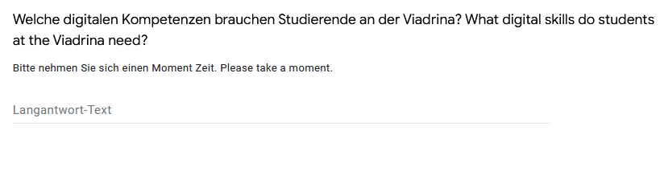

### All the data

Feather is a file format that can read and write faster. Storage is often reduced. The `arrow` package cannot read files from a web source (http). Download the file and use a local absolute or relative path to the data.

```r
library(arrow)
digital <- read_feather("Digital_Literacy_EN.feather")
library(tidyverse)
glimpse(digital)
```

```
## Rows: 77
## Columns: 12
## $ Research    <int> 5, 5, 4, 4, 5, 4, 4, 5, 4, 2, 4, 4, 2, 4, 4, 5, 3, 4, 5, 3~
## $ Interaction <int> 5, 5, 3, 4, 1, 5, 4, 5, 5, 5, 5, 5, 5, 3, 4, 5, 4, 4, 5, 4~
## $ Identity    <int> 3, 3, 3, 4, 3, 4, 2, 5, 5, 5, 3, 4, 4, 3, 4, 5, 2, 4, 5, 4~
## $ Content     <int> 5, 4, NA, 3, 3, 4, 2, 4, 4, 1, 3, 4, 4, 4, 2, 3, 2, 4, 3, ~
## $ Privacy     <int> 4, 3, 2, 2, 5, 3, 2, 5, 4, 3, 4, 4, 3, 2, 1, 2, 2, 5, 3, 4~
## $ Problems    <int> 3, 2, 1, 4, 3, 2, 2, 5, 3, 4, 4, 3, 3, 2, 3, 4, 4, 5, 2, 3~
## $ Teaching    <int> 2, 4, 3, 4, 5, 1, 3, 5, 5, 5, 3, 4, 5, 4, 1, 5, 2, 5, 4, 4~
## $ Skills      <chr> "Excel", "Neben den grundlegenden Komputerkentnissen noch ~
## $ Faculty     <fct> Econ, Econ, Econ, Econ, Econ, Econ, Econ, Econ, Econ, Econ~
## $ Level       <chr> "Master", "Master", "Master", "Bachelor", "Bachelor", "Bac~
## $ Gender      <fct> Female, Male, Female, Female, Female, Male, Male, Female, ~
## $ Skills_EN   <chr> "Excel", "Besides the basic computer skills, some basic kn~
```

### The Open Answers

In the `digital` data there are German and English answers to the question what digital competencies are required by students at Viadrina.

```r
head(digital$Skills)
```

```
## [1] "Excel"
## [2] "Neben den grundlegenden Komputerkentnissen noch eininge Grundkentnissen von Microsoft und Google Leistungen (MS Office, Google drive etc.). Außerdem gibt's an Viadrina keine hohe digitale Voraussetzungen. "
## [3] ""
## [4] "Ganz viel, ich habe das Gefühl dass meine Mitstudierenden keine Ahnung haben wie man richtig mit digitalen Medien umgeht und auch Programmen wie Office"
## [5] ""
## [6] "Digital research, Data visualisation / Content creation, Digital security and Legal literacy in the respective area"
```

# Translate Everything To English

## Deepl API

Use *Deepl* to translate all German responses in `digital$Skills` into English. There are options:

- Use website manually https://www.deepl.com/translator
- Use Deepl API and R in a programmatic way https://www.deepl.com/pro#developer

An application programming interface (**API**) is another piece of software that connects computer programs. It is a type of software interface, offering a service to other pieces of software.

Registration for the track **DeepL API Free** at https://www.deepl.com/pro#developer requires credit card information for identity check (but no payment). The documentation tells what is included in this pricing model: *DeepL API Free is a variant of our DeepL API Pro plan that allows developers to translate up to 500,000 characters per month for free.* https://support.deepl.com/hc/en-us/articles/360021200939-DeepL-API-Free

## Deeplr

Use `deeplr`, a package that offers an interface to the **Deepl API** (use free version). Some packages are not yet released on the official CRAN server. Good packages can be found on GitHub.

- https://github.com/zumbov2/deeplr

Use **devtools** to install this package from the GitHub repo. The aim of `devtools` is to make package development easier by providing R functions that simplify and expedite common tasks.

```r
install.packages("devtools")
devtools::install_github("zumbov2/deeplr")
```

Using the API inside R requires at least one authentication key (password).

Do not show or store your auth keys in a script.

```r
deeplr::usage2("KEY")
```

```
## $character_count
## [1] 7535
##
## $character_limit
## [1] 500000
```

```r
# deeplr::translate2(
#   text = "R ist eine freie Programmiersprache für statistische Berechnungen und Grafiken. Sie wurde 1992 von Statistikern für Anwender mit statistischen Aufgaben neu entwickelt.",
#   target_lang = "EN",
#   auth_key = "KEY"
#   )
```

[output not shown]

# Text Analysis

For this analysis we focus on the intro information on R from English Wikipedia.

```r
library(wikifacts)
R_EN <- wiki_define('R (programming language)')
R_EN
```

```
##                                                                                                                                                                                                                                                                                                          …
## "R is a programming language for statistical computing and graphics supported by the R Core Team and the R Foundation for Statistical Computing. Created by statisticians Ross Ihaka and Robert Gentleman, R is used among data miners, bioinformaticians and statisticians for data analysis and develop…
```

## Cleaning

Load the `tidytext` package. We summarize individual tasks like removing digits, punctuation, whitespaces and seting everything to lower case in the `clean_text()` function. There is a newline operator `\n` left. You can replace it with uncommenting the last command.

```r
library(tidytext)

# text cleaning
clean_text <- function(x) {
  x %>%
    # Remove digits
    str_remove_all("[:digit:]") %>%
    # Remove punctuation
    str_remove_all("[[:punct:]]") %>%
    # Make everything lowercase
    str_to_lower() %>%
    # Remove any trailing whitespace around the text
    str_trim("both") #%>%
    #str_replace_all("[\r\n]" , " ")
}
```

[output not shown]

## Tidytext Format

Tidy data has a specific structure:

- Each variable is a column
- Each observation is a row

We thus define the tidy text format as being a table with one-token-per-row. A token is a meaningful unit of text, such as a word, that we are interested in using for analysis, and tokenization is the process of splitting text into tokens.

```r
tidytext <- R_EN_clean %>%
  as_tibble() %>%
  unnest_tokens(word, value) %>%
  count(word, sort=TRUE)
head(tidytext)
```

```
## # A tibble: 6 x 2
##   word      n
##   <chr> <int>
## 1 r         8
## 2 the       8
## 3 and       6
## 4 of        5
## 5 is        4
## 6 data      3
```

## Stopwords

Stop words are a set of commonly used words in a language. Examples of stop words in English are “a”, “the”, “is”, “are” and etc. Stop words are commonly used in Text Mining and Natural Language Processing (NLP) to eliminate words that are so commonly used that they carry very little useful information.

```r
data(stop_words)

tidytext <- tidytext %>%
  anti_join(stop_words)
head(tidytext)
```

```
## # A tibble: 6 x 2
##   word            n
##   <chr>       <int>
## 1 data            3
## 2 language        3
## 3 programming     3
## 4 software        3
## 5 statistical     3
## 6 computing       2
```

## Term Frequency

Word clouds (also known as text clouds or tag clouds) work in a simple way: the more a specific word appears in a source of textual data (such as a speech, blog post, or database), the bigger and bolder it appears in the word cloud.

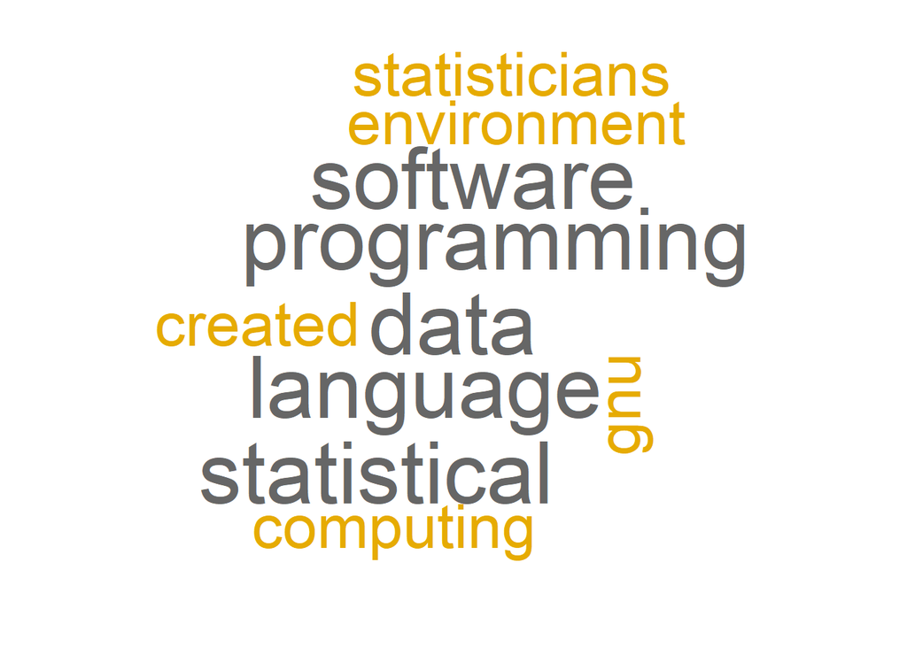

# Little bit of Scraping

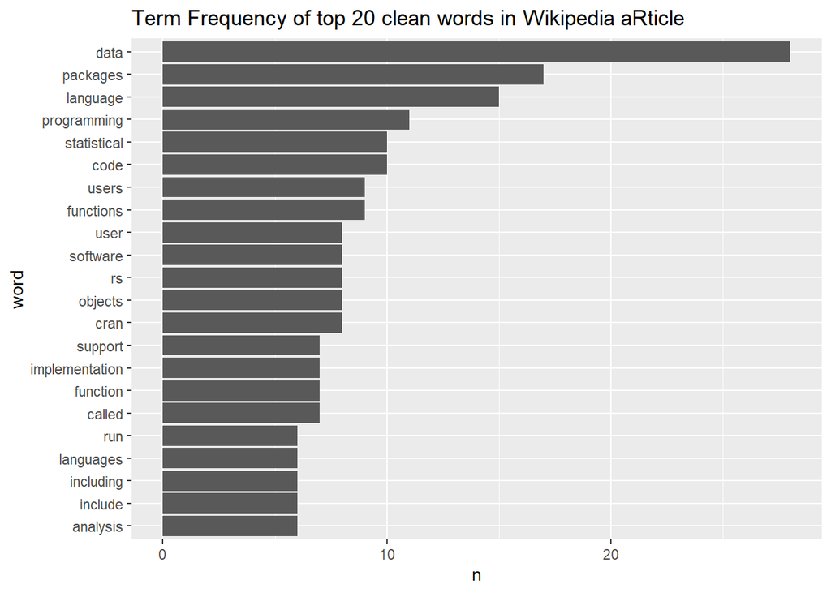

```r
library(rvest)

read_html("https://en.wikipedia.org/wiki/R_(programming_language)") %>%
  # extract paragraphs
  html_nodes("p")  %>%
  # extract text
  html_text() %>%
  # clean
  clean_text() %>%
  as_tibble() %>%
  # tidy text
  unnest_tokens(word, value) %>%
  count(word, sort=TRUE) %>%
  # stopwords
  anti_join(stop_words) %>%
  # select first
  top_n(20) %>%
  # reorder
  mutate(word = reorder(word, n)) %>%
  # create frequency plot
  ggplot(aes(x=word, y = n)) +
  geom_col() + coord_flip() +
  ggtitle("Term Frequency of top 20 clean words in Wikipedia aRticle")
```

[^1]: https://www.google.de/intl/en/forms/about/
[^2]: See https://www.soscisurvey.de/ and https://www.surveymonkey.de/